# Data Visualization: Group Solutions

PopBio REU 2018

Reni Kaul

Below are solutions for the different visualization challenges. As we saw, there are many paths to the same outcome. Here is just one.

# Challenge 1

Yesterday we explored the `nycflights13` dataset. One plot was a boxplot of the temperature by month using base `R`. The plot looked like this:

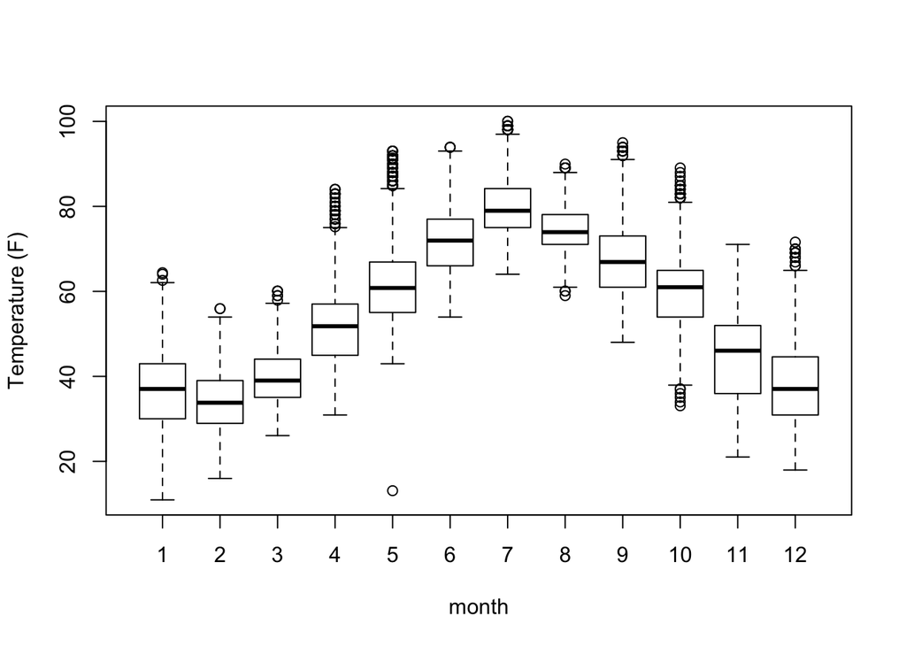

```r
library(nycflights13) #load data from package

boxplot(weather$temp ~ weather$month, xlab="month", ylab="Temperature (F)" ) #instead of assigning x and y values, you can use the syntax y ~ x
```

Today, your goal is to recreate this figure using the `ggplot2` package. `ggplot2` was first published to CRAN in 2005, so a quick google search will return *MANY* tutorials, discussion pages, etc. The general syntax for boxplots in `ggplot2` is:

```r
ggplot(data, #matrix
       aes(x= X.col, y= Y.col)) + #x and y columns in matrix to plot
      geom_boxplot() #plot the data as a box plot
```

## Solution

A polished `ggplot2` boxplot could look like this:

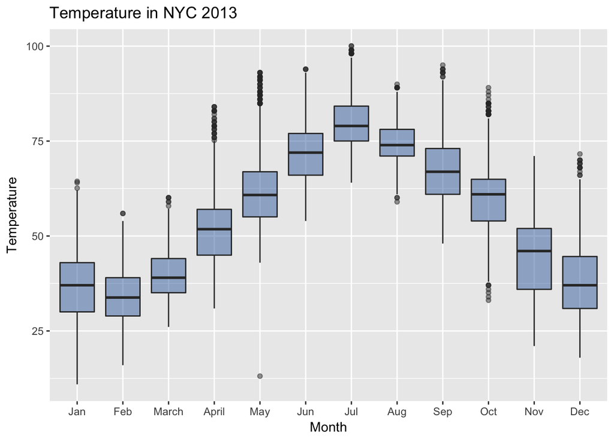

```r
library(ggplot2)

fill <- "#4271AE" #color of box fill
line <- "#1F3552" #color of box outline
weather$Month <- factor(weather$month,
                           labels = c("Jan","Feb","March", "April", "May", "Jun", "Jul", "Aug", "Sep", "Oct", "Nov", "Dec")) #convert month to ordered factor to automatically incorporate month label.

#plot
ggplot(weather, aes(x=Month, y=temp)) +  #indicate the data, x and y values
  geom_boxplot(fill=fill, line=line, alpha=0.5) + #add box plot layer
  scale_y_continuous(name="Temperature") + #label y axis
  ggtitle("Temperature in NYC 2013") #add title
```

A very detailed tutorial is on [ZevRoss](http://zevross.com/blog/2014/08/04/beautiful-plotting-in-r-a-ggplot2-cheatsheet-3/). A more formal guide is in the [R for Data Science](http://r4ds.had.co.nz/data-visualisation.html) visualization chapter.

# Group 1: Challenge 2 Scatter plot

For this exercise, we will use `mtcars` in the `datasets` package. Install (if needed) and load the `datasets` package. Explore the `mtcars` dataset which is from the 1974 *Motor Trend US* magazine, and comprises fuel consumption, engine metrics, etc. for 32 car models.

So far we have only created visualizations with 2 dimensions. We can add a third dimension to the data by coloring the plotted points. We can make a basic scatterplot of `mtcars` using `ggplot2`. Here the x-axis is car weight, y-axis mile per gallon, and color is the number of engine cylinders.

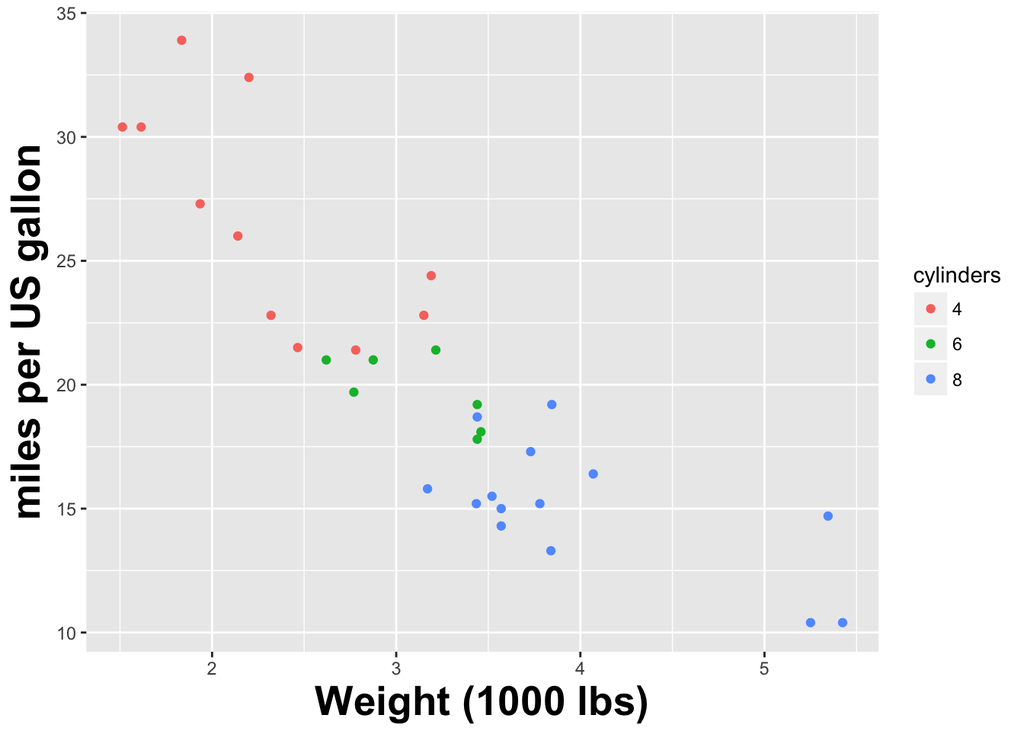

```r
ggplot(data = mtcars, aes(x = wt, y = mpg, color = as.factor(cyl))) + #set data, x,y and col values
         geom_point() + #add points layer
        scale_color_discrete(name="cylinders") + #change legend title
        labs(x="Weight (1000 lbs)",
             y="miles per US gallon") + #add x and y axis labels
        theme(axis.title = element_text(face = "bold", size=20)) #change font of both axis labels
```

# Grou 2: Challenge 2 Multi-panel plots

For this exercise, we will use `diamonds` in the `ggplot2` package. The `ggplot2` package should already be loaded. Explore the `diamonds` dataset which contains 10 attributes (price, cut, clarity, etc.) for ~54,000 diamonds.

So far we have only created single panel visualizations. Making multipanel visualizations is a quick way to look at trends between covariates. Here the x-axis is diamond carat, y-axis price, and each panel is diamond cut.

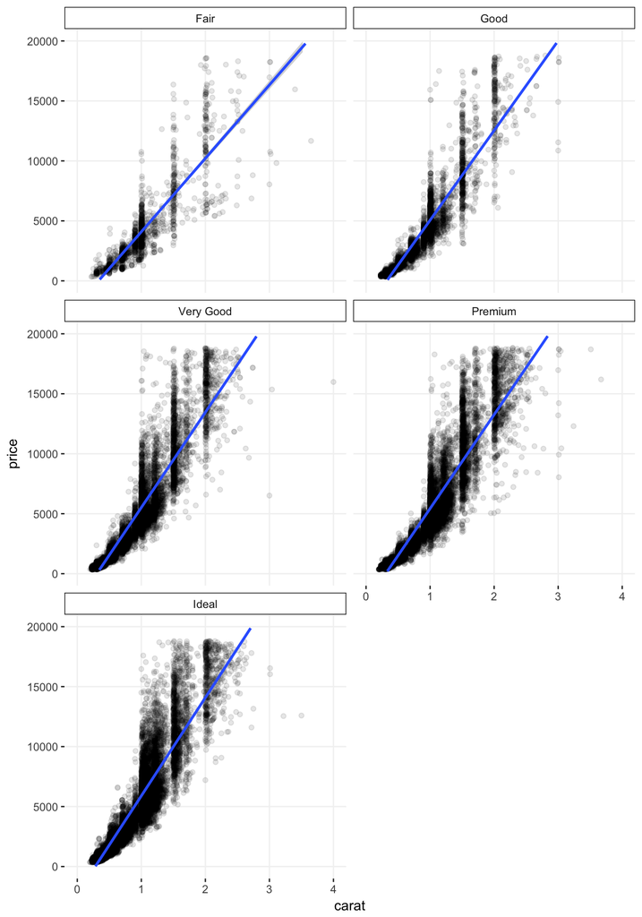

```r
ggplot(diamonds, aes(x=carat, y=price)) +
  geom_point(alpha = 0.1) +  #add points layes, making points transparent since so many
  scale_y_continuous(limits=c(0,20000))+ #set y limits
  scale_x_continuous(limits=c(0,4))+ #set x limits
  facet_wrap(~cut, ncol=2) + #make multipanel
  geom_smooth(method="lm") + #add regression line to plotted points
  theme(panel.background = element_rect(fill ="white"),
        panel.grid.major= element_line(colour="grey95"),
        strip.background = element_rect(colour = "black", fill="white")) #change color of backgrounds
```